# Statistical Comparison of Palestine and Israel

Omar Shakhtour

2023-03-16

## Introduction

This study is a statistical comparison of different types of data between Palestine and Israel.

This will give a comprehensive view of the difference between the two states. The topics covered include financial markers such as GDP, educational markers such as educational enrollment, and societal markers, such as refugee populations.

This study is important because it will highlight the vast difference between the two states, even though they were once one land together under the name of Palestine. But, after the partition of the state and the illegal abduction of Palestinian land, and the forced exile of the Palestinian people, we see a huge disparity between the two states. Israel is strongly supported by other nations and given significant sums of money to develop the state. Meanwhile, Palestine is struggling to survive under the iron fist of the Israeli occupation.

This study uses data from the World Bank. This data can be accessed here: https://data.worldbank.org/indicator?tab=featured

## Results

In the following code chunk we install the WDI and ggplot packages. The WDI package is used to access World Bank data, while the ggplot package is used for graphing the data.

```r
# install.packages("WDI")
# install.packages("ggplot2")
```

```r
library(WDI)
```

```r
library(ggplot2)
```

# Case Study 1: Financial Comparison

The following code displays a Bar Graph comparing the GDP of Palestine to that of Israel for the year 2020:

[figure not shown]

```r
gdp_data = WDI(country=c("PS", "IL"), indicator="NY.GDP.PCAP.KD", start=2020, end=2021, extra=TRUE)

ggplot(data = gdp_data, aes(x = country, y = NY.GDP.PCAP.KD, fill = country)) +
  geom_bar(stat = "identity") + scale_fill_manual(values=c("#0038b8","#009736")) +
  labs(title = "GDP comparison of Palestine and Israel in 2015",
       x = " ",
       y = "GDP per Capita in USD",
       fill = "Country")+
      theme(plot.title = element_text(hjust = 0.5))
```

The following code displays the degree of foreign investments in both states:

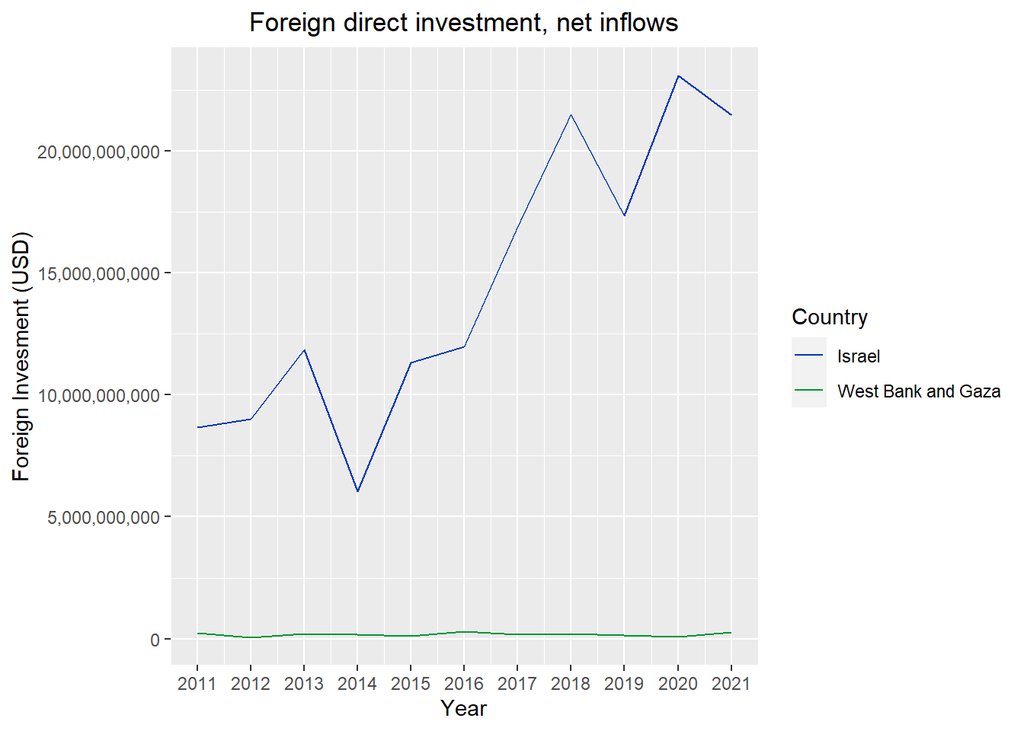

```r
gdp_data = WDI(country=c("PS", "IL"), indicator="BX.KLT.DINV.CD.WD", start=2011, end=2021, extra=TRUE)

invest <- ggplot(data = gdp_data, aes(x = year, y = BX.KLT.DINV.CD.WD, group = country)) +
  geom_line(aes(color = country)) + scale_color_manual(values=c("#0038b8", "#009736")) +
  labs(title = "Foreign direct investment, net inflows",
       x = "Year",
       y = "Foreign Invesment (USD)",
       color = "Country")+
      theme(plot.title = element_text(hjust = 0.5))

invest + scale_x_continuous(breaks = seq(min(gdp_data$year), max(gdp_data$year), by = 1)) + scale_y_continuous(labels=scales::comma)
```

# Case Study 2: Educational Comparison

The following code displays the percent of university-level school enrollment over 10 years in both states:

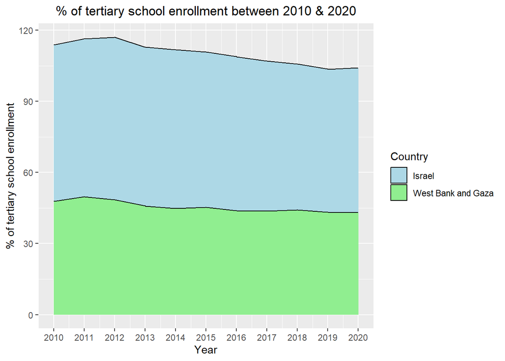

```r
gdp_data = WDI(country=c("PS", "IL"), indicator="SE.TER.ENRR", start=2010, end=2020, extra=TRUE)

invest <- ggplot(data = gdp_data, aes(x = year, y = SE.TER.ENRR, group = country)) +
  geom_area(aes(fill = country), color = "black") +
  scale_fill_manual(values=c("lightblue", "lightgreen")) +
  labs(title = "% of tertiary school enrollment between 2010 & 2020",
       x = "Year",
       y = "% of tertiary school enrollment",
       fill = "Country")+
      theme(plot.title = element_text(hjust = 0.5))

invest + scale_x_continuous(breaks = seq(min(gdp_data$year), max(gdp_data$year), by = 1)) + scale_y_continuous(labels=scales::comma)
```

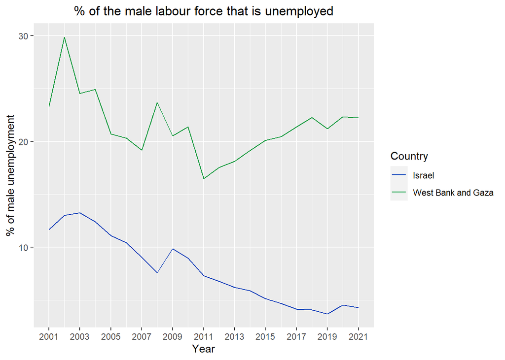

```r
gdp_data = WDI(country=c("PS", "IL"), indicator="SL.UEM.TOTL.MA.ZS", start=2001, end=2021, extra=TRUE)

invest <- ggplot(data = gdp_data, aes(x = year, y = SL.UEM.TOTL.MA.ZS, group = country)) +
  geom_line(aes(color = country)) + scale_color_manual(values=c("#0038b8", "#009736")) +
  labs(title = "% of the male labour force that is unemployed",
       x = "Year",
       y = "% of male unemployment",
       color = "Country")+
      theme(plot.title = element_text(hjust = 0.5))

invest + scale_x_continuous(breaks = seq(min(gdp_data$year), max(gdp_data$year), by = 2)) + scale_y_continuous(labels=scales::comma)
```

# Case Study 3: Social Development Comparison

The following code displays a bar graph of the refugee population by country of origin:

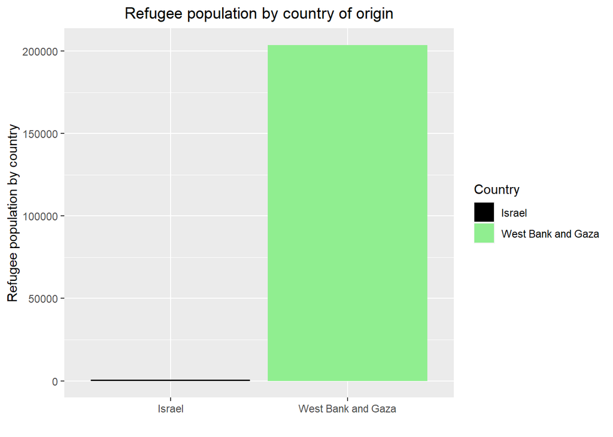

```r
gdp_data = WDI(country=c("PS", "IL"), indicator="SM.POP.REFG.OR", start=2020, end=2021, extra=TRUE)

ggplot(data = gdp_data, aes(x = country, y = SM.POP.REFG.OR, fill = country)) +
  geom_bar(stat = "identity") + scale_fill_manual(values=c("black","lightgreen")) +
  labs(title = "Refugee population by country of origin",
       x = " ",
       y = "Refugee population by country",
       fill = "Country")+
      theme(plot.title = element_text(hjust = 0.5))
```

## Discussion

As we witnessed in the results section, there is a huge disparity between Palestine and Israel in different categories.

All these graphs are connected in some way. The lack of foreign investments in Palestine contributes to the lack of development and infrastructure. This in turn contributes to the low GDP in Palestine. The low GDP means a weaker economy, when is tied to less jobs and more unemployment. Therefore, when there is financial struggle in this regard tertiary education goes on the back burner and it is not a priority in people’s lives.

If we take a look at history, the Nakba in 1948 was the forced exiling of Palestinians by the Israeli government. This, coupled with the continued illegal Israeli settlements that is slowly stealing Palestinian land, gives context to the massive number of refugees we saw in the fifth graph.

## Conclusion

To conclude, this study has shown:

- There is a huge disparity between Palestine and Israel in the areas of finance, education, and society.
- Many of the statistics shown about Palestine are directly or indirectly tied to one another.
- It is clear that the the history of the past century is significantly correlated to the current statistics.

Such a study can be useful for those looking to understand how the illegal Israeli occupation has significantly impacted the Palestinian people. The study can be used to help present data and inform people so that a significant change can be made.